# Entregable Bioinformatica

```r
library(tibble)
```

```r
rm(list = ls())
```

# Introducción a R y organización de proyectos bioinformáticos

## 3. Objetos y estructuras de datos en R

### Ejercicio 1. Vectores y selección

Crea los vectores `ids <- c("g1", "g2", "g3", "g4", "g5")` y `tam <- c(90, 450, 310, 120, 600)`.

1. Selecciona el tercer identificador.

```r
ids <- c("g1", "g2", "g3", "g4", "g5")
tam <- c(90, 450, 310, 120, 600)
cat(ids[3])
```

```
g3
```

2. Recupera los identificadores de genes con longitud de al menos 300.

```r
cat(ids[tam >= 300])
```

```
g2 g3 g5
```

3. Cuenta cuántos cumplen esa condición sin usar un ciclo

```r
sum(tam >= 300)
```

```
[1] 3
```

### Ejercicio 2: Factores

Crea una vector con las letras `A M A B M M B A B B`, donde `A` significa Alto, `B` bajo y `M` medio. Convierte las entradas del vector a factores y especifica que `A > M > B`.

```r
vector_letras = c("A", "M", "A", "B", "M", "M", "B", "A", "B", "B")

factor_ordenado = factor(
  vector_letras,
  levels = c("B", "M", "A"),
  ordered = TRUE
)

cat(factor_ordenado)
```

```
3 2 3 1 2 2 1 3 1 1
```

### Ejercicio 3. elegir estructuras

1. Construye un `data.frame` con tres genes, sus longitudes y una etiqueta funcional.

```r
Dataframe = tibble(
  gen = c("APOB", "LDLR", "PCSK9"),
  Longuitud = c("4536", "839", "692"),
  Funcion = c("Transporte", "Receptor", "Regulador")
  )
Dataframe
```

```
# A tibble: 3 × 3
  gen   Longuitud Funcion
  <chr> <chr>     <chr>
1 APOB  4536      Transporte
2 LDLR  839       Receptor
3 PCSK9 692       Regulador
```

2. Recupera únicamente las filas con longitud mayor que 200.

```r
Dataframe[Dataframe$Longuitud >200, ]
```

```
# A tibble: 3 × 3
  gen   Longuitud Funcion
  <chr> <chr>     <chr>
1 APOB  4536      Transporte
2 LDLR  839       Receptor
3 PCSK9 692       Regulador
```

3. Crea una lista que contenga la tabla y el identificador de una muestra.

```r
Lista <- list(muestra = "M01", genes = Dataframe)
Lista
```

```
$muestra
[1] "M01"

$genes
# A tibble: 3 × 3
  gen   Longuitud Funcion
  <chr> <chr>     <chr>
1 APOB  4536      Transporte
2 LDLR  839       Receptor
3 PCSK9 692       Regulador
```

4. Explica por qué una matriz de caracteres no sería una buena sustitución para la tabla cuando queremos conservar longitudes numéricas

Porque la matriz de caracteres se basa en palabras, y seria incorrecto tratar una palabra como un numero.

## 4. Estructuras de control

### Ejercicio 1. Clasificación de un valor

Define una variable `conteo` que represente el número de lecturas asignadas a un gen. Escribe un condicional que imprima:

- `"Dato faltante"` si el valor es `NA`.
- `"Conteo inválido"` si es negativo.
- `"Sin lecturas"` si es cero.
- `"Con lecturas"` si es positivo.

Prueba tu código con `NA`, `-2`, `0` y `15`.

```r
conteo <- 15

if (is.na(conteo)) {
  cat("Dato faltante")
} else if (conteo < 0) {
  cat("Conteo inválido")
} else if (conteo == 0) {
  cat("Sin lecturas")
} else {
  cat("Con lecturas")
}
```

```
Con lecturas
```

### Ejercicio 2. Verificación de conteos

Considera el vector `conteos <- c(8, 0, 13, 5, 0, 21)`. Utiliza las funciones anteriores para:

1. Verificar si todos los valores son no negativos.

```r
conteos <- c(8, 0, 13, 5, 0, 21)
cat(conteos >= 0)
```

```
TRUE TRUE TRUE TRUE TRUE TRUE
```

2. Determinar si existe al menos un conteo mayor que 20.

```r
cat(all(conteos >= 20))
```

```
FALSE
```

3. Obtener las posiciones de los conteos iguales a cero.

```r
cat(which(conteos == 0))
```

```
2 5
```

4. Crear un vector que indique `"Presente"` o `"Ausente"` según si el conteo es mayor que cero.

```r
cat(ifelse(conteos > 0, "Presente", "Ausente"))
```

```
Presente Ausente Presente Presente Ausente Presente
```

### Ejercicio 3. Longuitudes de secuencias

A partir del vector:

```r
secuencias <- c("ATG", "ATGCGT", "AATTCCGG", "CG")
```

1. Utiliza un ciclo `for` para guardar las longitudes en un vector llamado `longitudes`.

```r
longitudes <- numeric(length(secuencias))

for (i in seq_along(secuencias)) {
  longitudes[i] <- nchar(secuencias[i])
}
```

2. Crea otro vector llamado `clasificacion` que contenga `"Corta"` para longitudes menores que 5 y `"Larga"` para longitudes de al menos 5.

```r
clasificacion <- character(length(secuencias))

for (i in seq_along(secuencias)) {
  longitudes[i] <- nchar(secuencias[i])

  if (longitudes[i] < 5) {
    clasificacion[i] <- "Corta"
  } else {
    clasificacion[i] <- "Larga"
  }
}
```

3. Muestra ambos vectores

```r
cat("Longitudes:", longitudes, "\n")
```

```
Longitudes: 3 6 8 2
```

```r
cat("Clasificación:", clasificacion)
```

```
Clasificación: Corta Larga Larga Corta
```

### Ejercicio 4. Alcanzar una longuitud

Imagina que estamos construyendo una secuencia mediante la adición de un nucleótido `"A"` en cada iteración. Escribe un ciclo `while` que comience con una cadena vacía y se detenga cuando la secuencia alcance **8 nucleótidos**. Muestra el resultado final.

```r
secuencia <- ""

while (nchar(secuencia) < 8) {
  secuencia <- paste0(secuencia, "A")
}

cat("secuencia:", secuencia, "\n")
```

```
secuencia: AAAAAAAA
```

```r
cat("Tamaño:", nchar(secuencia))
```

```
Tamaño: 8
```

## 5. Funciones en R

### Ejercicio 1: Función 1

Escribe una función llamada `empieza_con` que reciba una secuencia y un prefijo, y determine si la secuencia comienza con ese prefijo. Pruébala con `"ATGCGT"` y los prefijos `"ATG"` y `"TGA"`.

```r
empieza_con = function(secuencia, prefijo){
  startsWith(secuencia, prefijo)
}

secuencia = "ATGCGT"
cat(empieza_con(secuencia, "ATG"), "\n")
```

```
TRUE
```

```r
cat(empieza_con(secuencia, "TGA"))
```

```
FALSE
```

### Ejercicio 2: Función 2

Modifica `resumir_adn()` para que también devuelva la proporción de nucleótidos `G` y `C` respecto de la longitud total. Prueba la función con una secuencia no vacía.

```r
resumir_adn <- function(id, secuencia) {
  secuencia <- toupper(secuencia)
  bases <- strsplit(secuencia, split = "", fixed = TRUE)[[1]]
  longitud <- nchar(secuencia)
  conteo_gc <- sum(bases %in% c("G", "C"))
  proporcion_gc <- if (longitud > 0) conteo_gc / longitud else NA_real_

  list(
    id = id,
    longitud = longitud,
    conteo_gc = conteo_gc,
    proporcion_gc = proporcion_gc
  )
}

resultado <- resumir_adn("GEN_01", "ATGCGTAA")
resultado
```

```
$id
[1] "GEN_01"

$longitud
[1] 8

$conteo_gc
[1] 3

$proporcion_gc
[1] 0.375
```

### Ejercicio 3: Función 3

Crea una función llamada `clasificar_secuencias` que reciba un vector de secuencias y devuelva una lista con dos elementos:

- `validas`: las secuencias formadas únicamente por `A`, `C`, `G` y `T`.
- `invalidas`: las secuencias que contienen otros caracteres o valores faltantes.

Utiliza la función `revisar_secuencias()` del ejemplo anterior

```r
revisar_secuencias <- function(secuencias) {
  resultado <- logical(length(secuencias))

  for (i in seq_along(secuencias)) {
    secuencia <- secuencias[i]

    if (is.na(secuencia)) {
      resultado[i] <- FALSE
    } else {
      resultado[i] <- grepl("^[ACGT]+$", toupper(secuencia))
    }
  }

  resultado
}

clasificar_secuencias <- function(secuencias) {
  if (!is.character(secuencias)) {
    stop("El argumento 'secuencias' debe ser un vector de tipo carácter.")
  }

  es_valida <- revisar_secuencias(secuencias)

  list(
    validas = secuencias[es_valida],
    invalidas = secuencias[!es_valida]
  )
}

secuencias <- c("ATGCGT", "ACNTGA", "ttacga", NA)
clasificar_secuencias(secuencias)
```

```
$validas
[1] "ATGCGT" "ttacga"

$invalidas
[1] "ACNTGA" NA
```

### Ejercicio 4

Un archivo de secuencias ha sido representado en R mediante dos vectores:

```r
ids <- c("seq_01", "seq_02", "seq_03", "seq_04")
secuencias <- c("ATGCGT", "ACNTGA", "GGCCAA", "TTTAAA")
```

Escribe una función `crear_reporte_secuencias(ids, secuencias)` que:

1. Compruebe que ambos argumentos son vectores de caracteres y tienen la misma longitud.
2. Identifique las secuencias válidas mediante `revisar_secuencias()`.
3. Devuelva un `data.frame` con las columnas `id`, `secuencia`, `longitud`y `valida`.
4. Asigne `NA` a la longitud de las secuencias inválidas.

```r
crear_reporte_secuencias <- function(ids, secuencias) {
  if (!is.character(ids) || !is.character(secuencias)) {
    stop("Ambos argumentos ('ids' y 'secuencias') deben ser vectores de caracteres.")
  }

  if (length(ids) != length(secuencias)) {
    stop("Los vectores 'ids' y 'secuencias' deben tener la misma longitud.")
  }

  valida <- revisar_secuencias(secuencias)
  longitud <- nchar(secuencias)
  longitud[!valida] <- NA_integer_

  data.frame(
    id = ids,
    secuencia = secuencias,
    longitud = longitud,
    valida = valida,
    stringsAsFactors = FALSE
  )
}

ids <- c("seq_01", "seq_02", "seq_03", "seq_04")
secuencias <- c("ATGCGT", "ACNTGA", "GGCCAA", "TTTAAA")

crear_reporte_secuencias(ids, secuencias)
```

```
      id secuencia longitud valida
1 seq_01    ATGCGT        6   TRUE
2 seq_02    ACNTGA       NA  FALSE
3 seq_03    GGCCAA        6   TRUE
4 seq_04    TTTAAA        6   TRUE
```

## 6. Scripts, paquetes y proyectos de R

### Ejercicio 1

Considera el siguiente código, guardado en un archivo llamado `revision.R`:

```r
longitudes <- nchar(secuencias)
resultado <- data.frame(id = ids, longitud = longitudes)
print(resultado)
```

```
      id longitud
1 seq_01        6
2 seq_02        6
3 seq_03        6
4 seq_04        6
```

Un estudiante afirma que el archivo funciona porque obtuvo una tabla al ejecutarlo en su computadora.

1. ¿Por qué podría fallar si otra persona abre el archivo y lo ejecuta desde una sesión nueva de R?  
   Porque puede que las versiones de los comandos haya cambiaando depenidendo de la versión, por lo que la sintaxis u el resultado prodria ser erroneo
2. ¿Cómo se puede modificar el script para que pueda ejecutarse completo sin depender de objetos creados previamente en la consola?  
   Declarando la version que se desea ocupar con el comando remotes::install_version(“nombre_paquete”, version = “x.y.z”)

# Importación y exploración de datos bioinformáticos en R

## 7. Importación y exploración de datos bioinformáticos en R

### Ejercicio 1: Reconocer un archivo antes de abrirlo

Sin abrirlo en una hoja de cálculo, utiliza R para comprobar que existe `blast_separador_incorrecto.csv`, mostrar sus tres primeras líneas y determinar qué separador utiliza realmente.

```r
# Comprobar que existe
file.exists("data_raw/datos_sesion_02_blast/blast_separador_incorrecto.csv")
```

```
[1] TRUE
```

```r
# Observar sus primeras 3 lineas
readLines("data_raw/datos_sesion_02_blast/blast_separador_incorrecto.csv", n = 3)
```

```
[1] "query_id\tsubject_id\tpident\tlength\tevalue\tbitscore"
[2] "seq01\tref_001\t87.9\t216\t1.00e-40\t118.7"
[3] "seq01\tref_002\t68.2\t245\t1.00e-36\t184.6"
```

Se puede observar que usa separadores de tabuladores, lo que no coincide con su nombre, puesto que deberia llamarse .tsv

### Ejercicio 2: Elegir la función adecuada

Importa `metadata_secuencias.csv` y `blast_comentarios.tsv` utilizando `readr`. Conserva `codigo_muestra` como texto. Comprueba la clase de cada objeto y muestra sus primeras filas

```r
# Cargar libreria
library(readr)
# Importar tibbles
metadata_secuencias.csv = read_csv("data_raw/datos_sesion_02_blast/metadata_secuencias.csv", show_col_types = FALSE)
blast_comentarios.tsv = read_tsv("data_raw/datos_sesion_02_blast/blast_comentarios.tsv", show_col_types = FALSE)
```

Comprobar clases de los dos tibbles

```r
class(metadata_secuencias.csv)
```

```
[1] "spec_tbl_df" "tbl_df"      "tbl"         "data.frame"
```

```r
class(blast_comentarios.tsv)
```

```
[1] "spec_tbl_df" "tbl_df"      "tbl"         "data.frame"
```

Mostrar las primeras filas de cada uno

```r
head(metadata_secuencias.csv)
```

```
# A tibble: 6 × 4
  query_id organismo  origen codigo_muestra
  <chr>    <chr>      <chr>  <chr>
1 seq01    Bacteria_A suelo  001
2 seq02    Bacteria_B agua   002
3 seq03    Bacteria_C suelo  003
4 seq04    Bacteria_A agua   004
5 seq05    Bacteria_B suelo  005
6 seq06    Bacteria_C agua   006
```

```r
head(blast_comentarios.tsv)
```

```
# A tibble: 6 × 1
  `# Resultado ilustrativo, no generado por BLAST`
  <chr>
1 "# Columnas: query_id, subject_id, pident, length, evalue, bitscore"
2 "query_id\tsubject_id\tpident\tlength\tevalue\tbitscore"
3 "seq01\tref_001\t87.9\t216\t1.00e-40\t118.7"
4 "seq01\tref_002\t68.2\t245\t1.00e-36\t184.6"
5 "seq01\tref_003\t93.5\t168\t1.00e-35\t386.1"
6 "seq02\tref_004\t82.6\t111\t1.00e-85\t259.9"
```

### Ejercicio 3: Explorar resultados tipo blast

Con `resultados_blast.tsv`, responde mediante código:

```r
# Importar resultados_blast.tsv
resultados_blast.tsv = read_tsv("data_raw/datos_sesion_02_blast/resultados_blast.tsv", show_col_types = FALSE)
```

1. ¿Cuántos registros y columnas tiene la tabla?

Numero de registros:

```r
nrow(resultados_blast.tsv)
```

```
[1] 20
```

```r
ncol(resultados_blast.tsv)
```

```
[1] 6
```

2. ¿Cuántos `query_id` diferentes aparecen?

```r
length(unique(resultados_blast.tsv$query_id))
```

```
[1] 8
```

3. ¿Cuántos resultados tiene cada consulta?

```r
table(resultados_blast.tsv$query_id)
```

```
seq01 seq02 seq03 seq04 seq05 seq06 seq07 seq08
    3     2     4     1     3     2     3     2
```

4. ¿Qué filas tienen `pident` mayor o igual a 95?

```r
resultados_blast.tsv[resultados_blast.tsv$pident >= 95, ]
```

```
# A tibble: 3 × 6
  query_id subject_id pident length evalue bitscore
  <chr>    <chr>       <dbl>  <dbl>  <dbl>    <dbl>
1 seq03    ref_009      97.8    191  1e-71     97.9
2 seq03    ref_010      99      229  1e- 8    336.
3 seq07    ref_019      95.7    106  1e-70    138.
```

5. ¿Hay valores faltantes?

```r
table(is.na(resultados_blast.tsv))
```

```
FALSE
  120
```

### Ejercicio 4: Detectar un problema de lectura

Un estudiante importa `blast_separador_incorrecto.csv` con `read_csv()` y obtiene una sola columna. ¿Significa que el archivo contiene una única variable? Explica cómo comprobarlo y corrige la importación.

```r
# Leer lineas para ver su separador
readLines("data_raw/datos_sesion_02_blast/blast_separador_incorrecto.csv", n = 5)
```

```
[1] "query_id\tsubject_id\tpident\tlength\tevalue\tbitscore"
[2] "seq01\tref_001\t87.9\t216\t1.00e-40\t118.7"
[3] "seq01\tref_002\t68.2\t245\t1.00e-36\t184.6"
[4] "seq01\tref_003\t93.5\t168\t1.00e-35\t386.1"
[5] "seq02\tref_004\t82.6\t111\t1.00e-85\t259.9"
```

El problema esta en que a pesar de que el archivo tiene terminación .csv, este no esta separado por comas, sino por tabuladores, por lo que lo correcto seria que se llamase `blast_separador_incorrecto.tsv` , dado que no cambiaremos el nombre, simplemte se leera como .tsv

```r
blast_separador_incorrecto.tsv = read_tsv("data_raw/datos_sesion_02_blast/blast_separador_incorrecto.csv", show_col_types = FALSE)
blast_separador_incorrecto.tsv
```

```
# A tibble: 20 × 6
   query_id subject_id pident length evalue bitscore
   <chr>    <chr>       <dbl>  <dbl>  <dbl>    <dbl>
 1 seq01    ref_001      87.9    216  1e-40    119.
 2 seq01    ref_002      68.2    245  1e-36    185.
 3 seq01    ref_003      93.5    168  1e-35    386.
 4 seq02    ref_004      82.6    111  1e-85    260.
 5 seq02    ref_005      68.7    292  1e-57    323.
 6 seq03    ref_007      88.2    254  1e- 5    362.
 7 seq03    ref_008      93.6    319  1e-36     96.6
 8 seq03    ref_009      97.8    191  1e-71     97.9
 9 seq03    ref_010      99      229  1e- 8    336.
10 seq04    ref_010      83.9    162  1e-62    310.
11 seq05    ref_013      75      101  1e-26    411.
12 seq05    ref_014      88      306  1e-23    175.
13 seq05    ref_015      85.4    287  1e-12    160.
14 seq06    ref_016      80.8    314  1e-49     49.8
15 seq06    ref_017      71.3    210  1e-26    226.
16 seq07    ref_019      95.7    106  1e-70    138.
17 seq07    ref_020      73      325  1e-75     79.3
18 seq07    ref_021      77.4    104  1e-54    174.
19 seq08    ref_022      69.9    205  1e-75    306.
20 seq08    ref_023      68.8    308  1e-63    152.
```

### Ejercicio 5: Reconocer secuencias FASTA

Utiliza `readLines()` y `grep()` para identificar los encabezados de `secuencias.fasta`. ¿Cuántas entradas FASTA contiene el archivo? Muestra únicamente sus encabezados

```r
Lineas = readLines("data_raw/datos_sesion_02_blast/secuencias.fasta")
Encabezados = grep("^>", Lineas)
length(Encabezados)
```

```
[1] 8
```

### Ejercicio 6: De los archivos a una descripción de los datos

1. Comprobar que existen `resultados_blast.tsv`, `metadata_secuencias.csv` y `secuencias.fasta`.

```r
file.exists("data_raw/datos_sesion_02_blast/resultados_blast.tsv")
```

```
[1] TRUE
```

```r
file.exists("data_raw/datos_sesion_02_blast/metadata_secuencias.csv")
```

```
[1] TRUE
```

```r
file.exists("data_raw/datos_sesion_02_blast/secuencias.fasta")
```

```
[1] TRUE
```

2. Importar las dos tablas con `readr` y conservar `codigo_muestra` como texto.

```r
metadata_secuencias.csv = read.csv("data_raw/datos_sesion_02_blast/metadata_secuencias.csv",
                                   colClasses = c(codigo_muestra = "character"))
resultados_blast.tsv = read_tsv("data_raw/datos_sesion_02_blast/resultados_blast.tsv", show_col_types = FALSE)
```

3. Mostrar dimensiones, nombres y tipos de columnas.

```r
# Para metadata_secuencias.csv
dplyr::glimpse(metadata_secuencias.csv)
```

```
Rows: 8
Columns: 4
$ query_id       <chr> "seq01", "seq02", "seq03", "seq04", "seq05", "seq06", "…
$ organismo      <chr> "Bacteria_A", "Bacteria_B", "Bacteria_C", "Bacteria_A",…
$ origen         <chr> "suelo", "agua", "suelo", "agua", "suelo", "agua", "sue…
$ codigo_muestra <chr> "001", "002", "003", "004", "005", "006", "007", "008"
```

```r
# Para resultados_blast.tsv
dplyr::glimpse(resultados_blast.tsv)
```

```
Rows: 20
Columns: 6
$ query_id   <chr> "seq01", "seq01", "seq01", "seq02", "seq02", "seq03", "seq0…
$ subject_id <chr> "ref_001", "ref_002", "ref_003", "ref_004", "ref_005", "ref…
$ pident     <dbl> 87.9, 68.2, 93.5, 82.6, 68.7, 88.2, 93.6, 97.8, 99.0, 83.9,…
$ length     <dbl> 216, 245, 168, 111, 292, 254, 319, 191, 229, 162, 101, 306,…
$ evalue     <dbl> 1e-40, 1e-36, 1e-35, 1e-85, 1e-57, 1e-05, 1e-36, 1e-71, 1e-…
$ bitscore   <dbl> 118.7, 184.6, 386.1, 259.9, 322.6, 361.9, 96.6, 97.9, 335.9…
```

4. Identificar los `query_id` distintos y contar los resultados por consulta.

```r
# Para metadata_secuencias.csv
length(unique(metadata_secuencias.csv$query_id))
```

```
[1] 8
```

```r
# Para resultados_blast.tsv
length(unique(resultados_blast.tsv$query_id))
```

```
[1] 8
```

5. Mostrar las filas con `pident >= 90` y explicar qué representa este filtro.

```r
# Para resultados_blast.tsv
resultados_blast.tsv[resultados_blast.tsv$pident >= 90,]
```

```
# A tibble: 5 × 6
  query_id subject_id pident length evalue bitscore
  <chr>    <chr>       <dbl>  <dbl>  <dbl>    <dbl>
1 seq01    ref_003      93.5    168  1e-35    386.
2 seq03    ref_008      93.6    319  1e-36     96.6
3 seq03    ref_009      97.8    191  1e-71     97.9
4 seq03    ref_010      99      229  1e- 8    336.
5 seq07    ref_019      95.7    106  1e-70    138.
```

Este resultado se puede interptetar como las secuencias que contienen un porcentaje de identidad mayor al 90% respecto a la secuencia que se dio

6. Leer el FASTA e indicar cuántos encabezados contiene.

```r
Lineas = readLines("data_raw/datos_sesion_02_blast/secuencias.fasta")
Encabezados = grep("^>", Lineas)
length(Encabezados)
```

```
[1] 8
```

7. Mostrar si alguna de las tablas tiene valores faltantes

```r
# Para metadata_secuencias.csv
table(is.na(metadata_secuencias.csv))
```

```
FALSE
   32
```

```r
# Para resultados_blast.tsv
table(is.na(resultados_blast.tsv))
```

```
FALSE
  120
```

# Manipulación y transformación de datos bioinformáticos con dplyr y tidyr

## 8. Manipulación y transformación de datos bioinformáticos con dplyr y tidyr

Descargar paquetes a ocupar

```r
library(readr)
library(dplyr)
library(dplyr)
library(tidyr)
library(tibble)
```

Cargar archivo

```r
expresion_genica_estres.csv = read_csv("data_raw/expresion_genica_estres.csv", show_col_types = FALSE)
```

## Ejercicio 1

#### Calcula el conteo promedio de cada gen en cada condición experimental

```r
PromedioEstres = expresion_genica_estres.csv %>%
  group_by(gene_id, condicion) %>%
  summarise(
    Promedio_por_condicion = mean(conteo),
    .groups = "drop_last"
  )
head(PromedioEstres)
```

```
# A tibble: 6 × 3
# Groups:   gene_id [3]
  gene_id  condicion Promedio_por_condicion
  <chr>    <chr>                      <dbl>
1 gene_001 Control                    1311
2 gene_001 Estres                      984.
3 gene_002 Control                     915
4 gene_002 Estres                      907.
5 gene_003 Control                     927.
6 gene_003 Estres                     1041.
```

#### Organiza los resultados de manera que puedas comparar los promedios de Control y Estrés para cada gen

```r
PromedioEstresAncho = PromedioEstres %>%
  pivot_wider(
    names_from = condicion,
    values_from = Promedio_por_condicion
  )

head(PromedioEstresAncho)
```

```
# A tibble: 6 × 3
# Groups:   gene_id [6]
  gene_id  Control Estres
  <chr>      <dbl>  <dbl>
1 gene_001   1311    984.
2 gene_002    915    907.
3 gene_003    927.  1041.
4 gene_004   1260.  1799.
5 gene_005    108.   167
6 gene_006    946.  1956
```

#### Calcula la razón entre el promedio en Estrés y el promedio en Control

```r
PromedioEstresAncho = PromedioEstresAncho %>%
  mutate(Razon = Estres/Control)
PromedioEstresAncho
```

```
# A tibble: 40 × 4
# Groups:   gene_id [40]
   gene_id  Control Estres Razon
   <chr>      <dbl>  <dbl> <dbl>
 1 gene_001   1311    984. 0.750
 2 gene_002    915    907. 0.992
 3 gene_003    927.  1041. 1.12
 4 gene_004   1260.  1799. 1.43
 5 gene_005    108.   167  1.54
 6 gene_006    946.  1956  2.07
 7 gene_007    751.  2160. 2.88
 8 gene_008    956.  4140  4.33
 9 gene_009    179.  1162. 6.50
10 gene_010   1124.   497  0.442
# ℹ 30 more rows
```

#### Identifica los cinco genes con mayor aumento relativo y muestra su anotación funcional

```r
PromedioEstresAncho %>%
  arrange(desc(Razon)) %>%
  head(PromedioEstresAncho, n = 5)
```

```
# A tibble: 5 × 4
# Groups:   gene_id [5]
  gene_id  Control Estres Razon
  <chr>      <dbl>  <dbl> <dbl>
1 gene_009    179.  1162.  6.50
2 gene_029    237.  1318.  5.57
3 gene_039    312   1717.  5.50
4 gene_028    452   2127.  4.71
5 gene_019    868.  4020.  4.63
```

#### **Pregunta de interpretación**

¿Un gen con un aumento relativo grande necesariamente presenta un conteo alto de lecturas?

No, un aumento relativo alto no implica necesariamente un conteo absoluto elevado de lecturas

## Ejercicio 2

#### Calcula el conteo promedio de cada gen considerando todas las muestras.

```r
PromedioTodasLasMuestras = expresion_genica_estres.csv %>%
  group_by(gene_id, funcion) %>%
  summarise(
    Conteo_Promedio = mean(conteo),
    .groups = "drop"
  )

PromedioTodasLasMuestras
```

```
# A tibble: 40 × 3
   gene_id  funcion                    Conteo_Promedio
   <chr>    <chr>                                <dbl>
 1 gene_001 Función desconocida                  1147.
 2 gene_002 Metabolismo de aminoácidos            911.
 3 gene_003 Síntesis de proteínas                 984
 4 gene_004 Síntesis de proteínas                1530.
 5 gene_005 Regulación transcripcional            138.
 6 gene_006 Replicación y reparación             1451.
 7 gene_007 Metabolismo energético               1456.
 8 gene_008 Metabolismo energético               2548.
 9 gene_009 Transporte de membrana                670.
10 gene_010 Respuesta al estrés                   811.
# ℹ 30 more rows
```

#### Identifica los 15 genes con mayor conteo promedio.

```r
Mayor_Promedio = PromedioTodasLasMuestras %>%
  arrange(desc(Conteo_Promedio))

head(Mayor_Promedio, n = 15)
```

```
# A tibble: 15 × 3
   gene_id  funcion                    Conteo_Promedio
   <chr>    <chr>                                <dbl>
 1 gene_018 Metabolismo energético               2990.
 2 gene_008 Metabolismo energético               2548.
 3 gene_019 Transporte de membrana               2444
 4 gene_017 Replicación y reparación             1807.
 5 gene_026 Regulación transcripcional           1669.
 6 gene_036 Síntesis de proteínas                1585.
 7 gene_004 Síntesis de proteínas                1530.
 8 gene_023 Metabolismo de aminoácidos           1463.
 9 gene_007 Metabolismo energético               1456.
10 gene_006 Replicación y reparación             1451.
11 gene_024 Metabolismo de aminoácidos           1445.
12 gene_015 Regulación transcripcional           1410.
13 gene_028 Replicación y reparación             1290.
14 gene_032 Respuesta al estrés                  1240.
15 gene_001 Función desconocida                  1147.
```

```r
frecuencia_categorias <- Mayor_Promedio |>
  count(funcion, name = "n_genes") |>
  arrange(desc(n_genes))

Mayor_Promedio
```

```
# A tibble: 40 × 3
   gene_id  funcion                    Conteo_Promedio
   <chr>    <chr>                                <dbl>
 1 gene_018 Metabolismo energético               2990.
 2 gene_008 Metabolismo energético               2548.
 3 gene_019 Transporte de membrana               2444
 4 gene_017 Replicación y reparación             1807.
 5 gene_026 Regulación transcripcional           1669.
 6 gene_036 Síntesis de proteínas                1585.
 7 gene_004 Síntesis de proteínas                1530.
 8 gene_023 Metabolismo de aminoácidos           1463.
 9 gene_007 Metabolismo energético               1456.
10 gene_006 Replicación y reparación             1451.
# ℹ 30 more rows
```

```r
frecuencia_categorias
```

```
# A tibble: 8 × 2
  funcion                    n_genes
  <chr>                        <int>
1 Metabolismo energético           6
2 Síntesis de proteínas            6
3 Función desconocida              5
4 Metabolismo de aminoácidos       5
5 Regulación transcripcional       5
6 Replicación y reparación         5
7 Respuesta al estrés              4
8 Transporte de membrana           4
```

#### **Pregunta de interpretación:**

¿La categoría funcional más frecuente entre estos 15 genes necesariamente es la más importante para la bacteria?

No necesariamente, ya que esta frecuencia puede estar determinada por otros factores, que si bien pueden estar correlacionados no significa que sean dependientes de la importancia

# Integración de datos y automatización de analisis en R

## 9. Integración de datos y automatización de analisis en R

```r
library(dplyr)
library(readr)
library(purrr)
```

```r
carpeta_datos <- "data_raw/datos_sesion_04_integracion"
carpeta_blast <- file.path(carpeta_datos, "blast_muestras")

if (!dir.exists("results")) {
  dir.create("results")
}
```

```r
carpeta_datos <- "data_raw/datos_sesion_04_integracion"
carpeta_blast <- file.path(carpeta_datos, "blast_muestras")


blast_A <- read_tsv(
  file.path(carpeta_blast, "muestra_A.tsv"),
  show_col_types = FALSE
)
blast_B <- read_tsv(
  file.path(carpeta_blast, "muestra_B.tsv"),
  show_col_types = FALSE
)
blast_C <- read_tsv(
  file.path(carpeta_blast, "muestra_C.tsv"),
  show_col_types = FALSE
)

metadata <- read_csv(
  file.path(carpeta_datos, "metadata_secuencias.csv"),
  col_types = cols(codigo_muestra = col_character(), .default = col_guess())
)
```

```r
blast_total <- bind_rows(
  muestra_A = blast_A,
  muestra_B = blast_B,
  muestra_C = blast_C,
  .id = "muestra"
)

blast_total
```

```
# A tibble: 21 × 7
   muestra   query_id subject_id pident length evalue bitscore
   <chr>     <chr>    <chr>       <dbl>  <dbl>  <dbl>    <dbl>
 1 muestra_A seq01    ref_001      87.9    216  1e-40    119.
 2 muestra_A seq01    ref_002      68.2    245  1e-36    185.
 3 muestra_A seq01    ref_003      93.5    168  1e-35    386.
 4 muestra_A seq02    ref_004      82.6    111  1e-85    260.
 5 muestra_A seq02    ref_005      68.7    292  1e-57    323.
 6 muestra_A seq03    ref_007      88.2    254  1e- 5    362.
 7 muestra_A seq03    ref_008      93.6    319  1e-36     96.6
 8 muestra_B seq03    ref_009      97.8    191  1e-71     97.9
 9 muestra_B seq03    ref_010      99      229  1e- 8    336.
10 muestra_B seq04    ref_010      83.9    162  1e-62    310.
# ℹ 11 more rows
```

```r
conteos_riz <- read_tsv("data_raw/datos_rizosfera/conteos_taxonomia_rizosfera.tsv",
  show_col_types = FALSE)

metadata_riz <- read_csv("data_raw/datos_rizosfera/metadata_rizosfera.csv",
  show_col_types = FALSE)
```

```r
niveles <- c(
  "kingdom", "phylum", "class", "order",
  "family", "genus", "species"
)

conteos_limpios <- conteos_riz %>%
  mutate(
    across(
      all_of(niveles),
      ~ na_if(sub("^[a-z]__", "", .x), "")
    )
  )

conteos_limpios %>%
  select(taxon_id, all_of(niveles)) %>%
  head()
```

```
# A tibble: 6 × 8
  taxon_id             kingdom  phylum    class   order     family genus species
  <chr>                <chr>    <chr>     <chr>   <chr>     <chr>  <chr> <chr>
1 Lactiplantibacillus  Bacteria Bacillota Bacilli Lactobac… Lacto… Lact… <NA>
2 Lactobacillus        Bacteria Bacillota Bacilli Lactobac… Lacto… Lact… <NA>
3 Ligilactobacillus    Bacteria Bacillota Bacilli Lactobac… Lacto… Ligi… <NA>
4 Limosilactobacillus  Bacteria Bacillota Bacilli Lactobac… Lacto… Limo… <NA>
5 Companilactobacillus Bacteria Bacillota Bacilli Lactobac… Lacto… Comp… <NA>
6 Leuconostoc          Bacteria Bacillota Bacilli Lactobac… Lacto… Leuc… <NA>
```

```r
ids_muestras <- metadata_riz$sample_id

conteos_largos <- conteos_limpios %>%
  pivot_longer(
    cols = all_of(ids_muestras),
    names_to = "sample_id",
    values_to = "conteo"
  )

datos_riz <- conteos_largos %>%
  left_join(
    metadata_riz %>% select(sample_id, host_name, country, year),
    by = "sample_id",
    relationship = "many-to-one"
  )

glimpse(datos_riz)
```

```
Rows: 249,750
Columns: 13
$ taxon_id  <chr> "Lactiplantibacillus", "Lactiplantibacillus", "Lactiplantiba…
$ kingdom   <chr> "Bacteria", "Bacteria", "Bacteria", "Bacteria", "Bacteria", …
$ phylum    <chr> "Bacillota", "Bacillota", "Bacillota", "Bacillota", "Bacillo…
$ class     <chr> "Bacilli", "Bacilli", "Bacilli", "Bacilli", "Bacilli", "Baci…
$ order     <chr> "Lactobacillales", "Lactobacillales", "Lactobacillales", "La…
$ family    <chr> "Lactobacillaceae", "Lactobacillaceae", "Lactobacillaceae", …
$ genus     <chr> "Lactiplantibacillus", "Lactiplantibacillus", "Lactiplantiba…
$ species   <chr> NA, NA, NA, NA, NA, NA, NA, NA, NA, NA, NA, NA, NA, NA, NA, …
$ sample_id <chr> "SRR12192850", "SRR13062011", "SRR11128413", "SRR12964294", …
$ conteo    <dbl> 87, 58, 63, 64, 55, 390, 245, 98, 106, 1937, 1048, 55, 58, 1…
$ host_name <chr> "Maize", "Maize", "Maize", "Maize", "Maize", "Sorghum", "Mai…
$ country   <chr> "South Africa", "South Africa", "South Africa", "South Afric…
$ year      <dbl> 2021, 2021, 2020, 2021, 2020, 2021, 2023, 2021, 2020, 2021, …
```

```r
totales_muestra <- datos_riz %>%
  group_by(sample_id) %>%
  summarise(total_lecturas = sum(conteo), .groups = "drop")

stopifnot(all(totales_muestra$total_lecturas > 0))
head(totales_muestra)
```

```
# A tibble: 6 × 2
  sample_id   total_lecturas
  <chr>                <dbl>
1 ERR5639101         1621386
2 SRR11092499        2714607
3 SRR11092502        3195156
4 SRR11092506        3058423
5 SRR11092508        2841362
6 SRR11092509        3348466
```

```r
preparar_abundancias <- function(tabla, nivel = "genus", umbral = 0.05) {
  niveles_validos <- c(
    "kingdom", "phylum", "class", "order",
    "family", "genus", "species"
  )

  stopifnot(
    nivel %in% niveles_validos,
    is.numeric(umbral), length(umbral) == 1,
    !is.na(umbral), umbral >= 0, umbral <= 1
  )

  etiqueta_otros <- if (nivel == "phylum") {
    "Filos < 5%"
  } else if (nivel == "genus") {
    "Géneros < 5%"
  } else {
    "Taxones < 5%"
  }

  tabla %>%
    mutate(
      taxon = .data[[nivel]],
      taxon = if_else(is.na(taxon) | taxon == "",
                      "Sin clasificar", taxon)
    ) %>%
    group_by(sample_id, host_name, taxon) %>%
    summarise(conteo = sum(conteo), .groups = "drop") %>%
    group_by(sample_id) %>%
    mutate(abundancia_relativa = conteo / sum(conteo)) %>%
    ungroup() %>%
    mutate(
      taxon_final = if_else(
        abundancia_relativa < umbral,
        etiqueta_otros,
        taxon
      )
    ) %>%
    group_by(sample_id, host_name, taxon_final) %>%
    summarise(
      abundancia_relativa = sum(abundancia_relativa),
      .groups = "drop"
    )
}

filo_5 = preparar_abundancias(datos_riz, "phylum")
View(filo_5)
genus_5 = preparar_abundancias(datos_riz, "genus")
View(genus_5)


write_tsv(genus_5, "results/generos_5.tsv")
write_tsv(filo_5, "results/filos_5.tsv")
```

```r
preparar_abundancias <- function(tabla, nivel = "genus", umbral = 0.05) {
  niveles_validos <- c(
    "kingdom", "phylum", "class", "order",
    "family", "genus", "species"
  )

  stopifnot(
    nivel %in% niveles_validos,
    is.numeric(umbral), length(umbral) == 1,
    !is.na(umbral), umbral >= 0, umbral <= 1
  )

  etiqueta_otros <- if (nivel == "phylum") {
    "Filos < 5%"
  } else if (nivel == "genus") {
    "Géneros < 5%"
  } else {
    "Taxones < 5%"
  }

  tabla %>%
    mutate(
      taxon = .data[[nivel]],
      taxon = if_else(is.na(taxon) | taxon == "",
                      "Sin clasificar", taxon)
    ) %>%
    group_by(sample_id, host_name, taxon) %>%
    summarise(conteo = sum(conteo), .groups = "drop") %>%
    group_by(sample_id) %>%
    mutate(abundancia_relativa = conteo / sum(conteo)) %>%
    ungroup() %>%
    mutate(
      taxon_final = if_else(
        abundancia_relativa < umbral,
        etiqueta_otros,
        taxon
      )
    ) %>%
    group_by(sample_id, host_name, taxon_final) %>%
    summarise(
      abundancia_relativa = sum(abundancia_relativa),
      .groups = "drop"
    )
}
```

# Construcción y exploración visual de datos bioinformáticos con ggplot2

## 10. Construcción y exploración visual de datos bioinformáticos con ggplot2

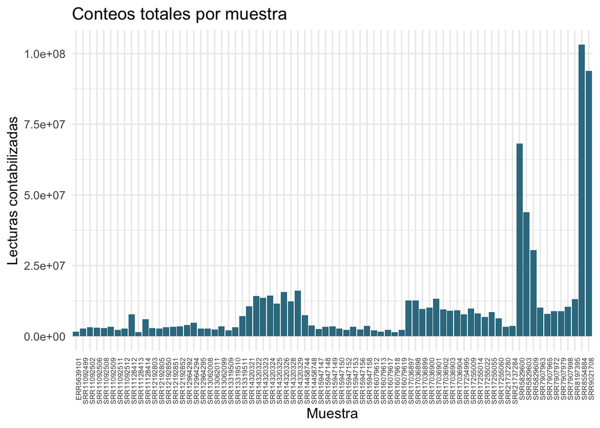

```r
library(ggplot2)

# Resultados procesados en la sesión anterior
generos_5 <- read_tsv("results/generos_5.tsv")

filos_5 <- read_tsv("results/filos_5.tsv")

totales_muestra <- read_tsv("results/totales_muestra.tsv")

# Metadatos originales
metadata_riz <- read_csv(
  "data_raw/datos_rizosfera/metadata_rizosfera.csv"
)

profundidad <- totales_muestra %>%
  left_join(
    metadata_riz %>%
      select(sample_id, host_name, country, crop_system),
    by = "sample_id",
    relationship = "one-to-one"
  )

stopifnot(!anyNA(profundidad$host_name))

p_profundidad <- ggplot(profundidad, aes(x = sample_id, y = total_lecturas)) +
  geom_col(fill = "#367A90") +
  labs(title = "Conteos totales por muestra", x = "Muestra",
       y = "Lecturas contabilizadas") +
  theme_minimal(base_size = 12) +
  theme(axis.text.x = element_text(angle = 90, hjust = 1, size = 6))
p_profundidad
```

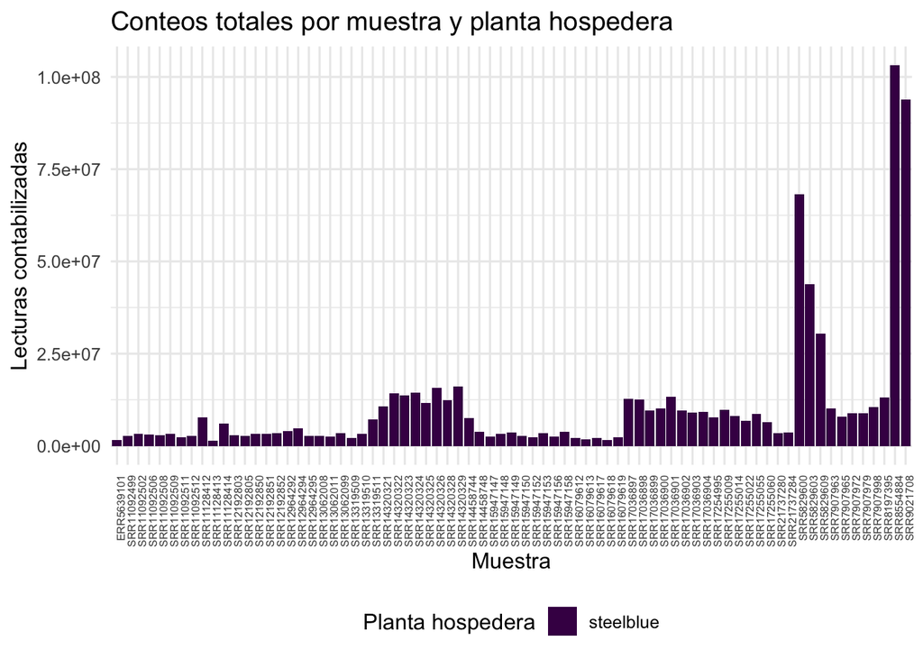

```r
p_profundidad_color <- ggplot(profundidad,
                             aes(x = sample_id, y = total_lecturas, fill = "steelblue")) +
  geom_col() +
  scale_fill_viridis_d(option = "viridis") +
  labs(title = "Conteos totales por muestra y planta hospedera",
       x = "Muestra", y = "Lecturas contabilizadas", fill = "Planta hospedera") +
  theme_minimal(base_size = 12) +
  theme(axis.text.x = element_text(angle = 90, hjust = 1, size = 6),
        legend.position = "bottom")
p_profundidad_color
```

### Pregunta

Si cambiamos aes(fill = host_name) por geom_col(fill = “steelblue”), ¿qué información deja de representar el color?

Los colores no cambiaran dependiendo del la planta hospedera, sino que todos seran del mismo color

### Pregunta

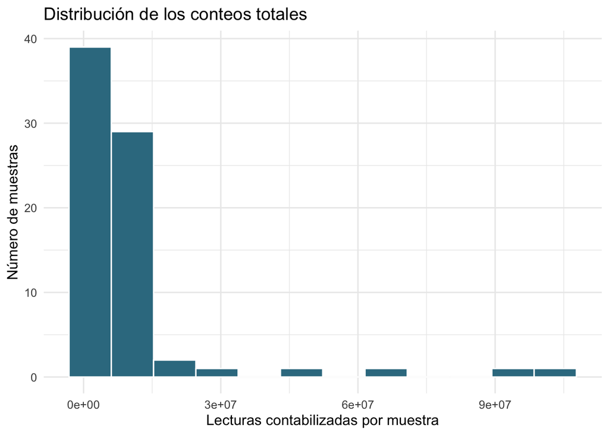

```r
p_hist <- ggplot(profundidad, aes(x = total_lecturas)) +
  geom_histogram(bins = 12, fill = "#367A90", color = "white") +
  labs(title = "Distribución de los conteos totales",
       x = "Lecturas contabilizadas por muestra", y = "Número de muestras") +
  theme_minimal(base_size = 12)
p_hist
```

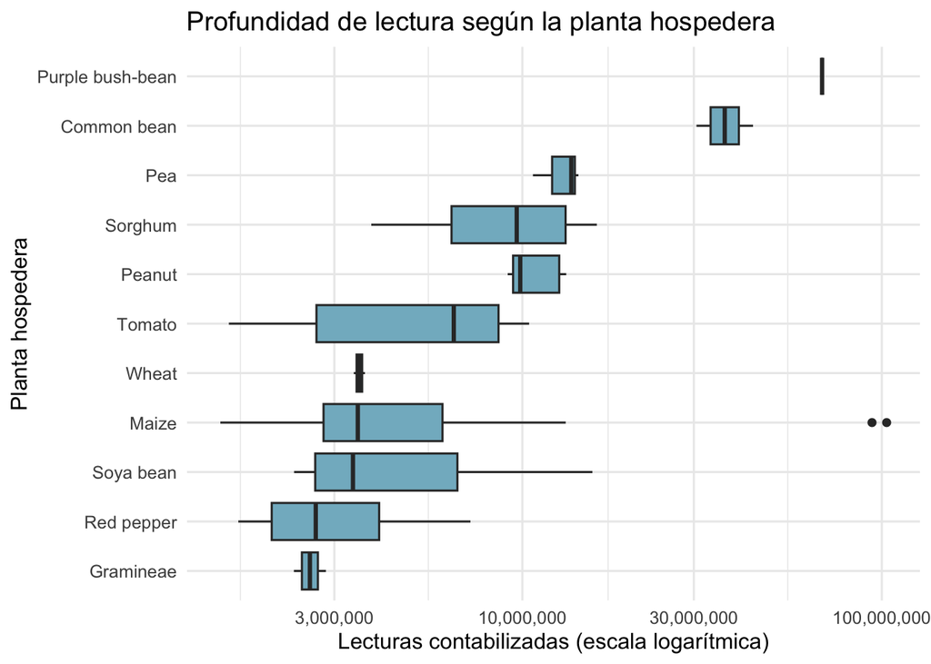

```r
ggplot(
  profundidad,
  aes(
    x = reorder(host_name, total_lecturas, FUN = median),
    y = total_lecturas
  )
) +
  geom_boxplot(fill = "#83B7C9") +
  scale_y_log10(labels = scales::label_comma()) +
  coord_flip() +
  labs(
    title = "Profundidad de lectura según la planta hospedera",
    x = "Planta hospedera",
    y = "Lecturas contabilizadas (escala logarítmica)"
  ) +
  theme_minimal(base_size = 12)
```

¿El histograma y el diagrama de caja muestran el número de lecturas de cada muestra identificada? No, lo que las graficas muestran es el resumen de sus distribuciones, no el número de lecturas

¿Por qué resulta útil utilizar una escala logarítmica en esta figura? ¿Podemos concluir que las plantas con mayor profundidad de lectura tienen una mayor abundancia de microorganismos? Al ver como logaritmo se permite observar cantidades con magnitudes diferentes, de modo que la visualización no se vea sezgada hacia un lado.